# BE/BAT 485/585

## Now try to understand what the following code is doing and what kind of useful info we are extracting

```
<function TextIOWrapper.close()>
```

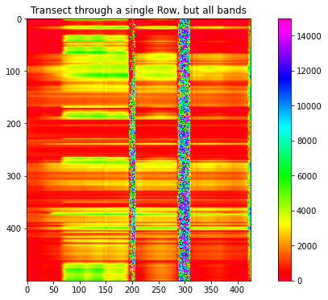

```python
# for the same row, extract a profile through all bands now - remember this is hyperspctral data
# So lots of bands will show up and notice the slicing approach
# We only defined the Row = 100 and used all columns [:] and all bands [:]

Profile=DataCube[100,:,:]
plt.figure(figsize=(12,6))
plt.title('Transect through a single Row, but all bands')
plt.imshow(Profile,cmap='gist_rainbow')
plt.colorbar()

# Read the wavelength values from the textfile
file = open('NEON_wavelength_values2.txt', 'r')
Xvalues= file.readlines()
nvalues=len(Xvalues)

#convert text to number (float)
for i in range(0,nvalues):
  Xvalues[i]=float(Xvalues[i])

# close text file
file.close
```

```python
# Read the wavelength values from the textfile
file = open(r'../Lab4/NEON_wavelength_values.txt', 'r')
Xvalues= file.readlines()
nvalues=len(Xvalues)

#convert text to number (float)
for i in range(0,nvalues):
  Xvalues[i]=float(Xvalues[i])

# close text file
file.close
```

```
<function TextIOWrapper.close()>
```

```python
print(len(Xvalues))
```

```
426
```

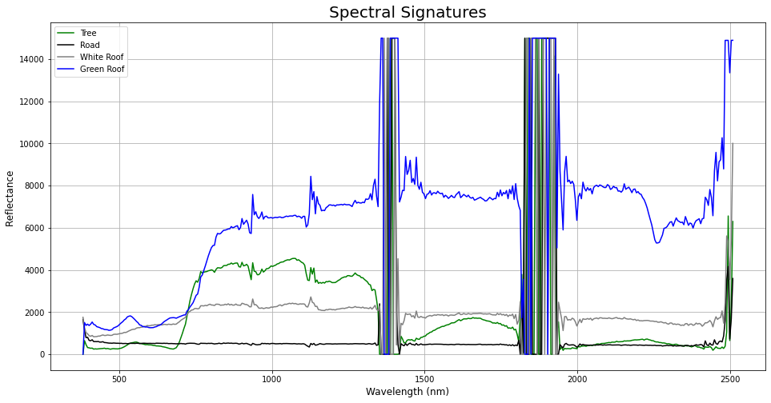

```python
# Extract a single pixel through all bands now to develop a spectral signature
# Example:
Tree_Spectra=DataCube[70,85,:]
Road_Spectra=DataCube[100,200,:]
White_Roof_Spectra=DataCube[120,265,:]
Green_Roof_Spectra=DataCube[445,388,:]

plt.figure(figsize=(16,8))
plt.title('Spectral Signatures',fontsize=20)
plt.xlabel('Wavelength (nm)',fontsize=12)
plt.ylabel('Reflectance ',fontsize=12)
plt.plot(Xvalues,Tree_Spectra,color='green',label='Tree')
plt.plot(Xvalues,Road_Spectra,color='black',label='Road')
plt.plot(Xvalues,White_Roof_Spectra,color='grey',label='White Roof')
plt.plot(Xvalues,Green_Roof_Spectra,color='blue',label='Green Roof')

plt.grid()
plt.legend(loc='upper left')
```

# Homework: To do

- Your job is now is to extract a transect through a diangonal line
- Plot the data and label it (indictae location of transect) on the image

```python
Red=DataCube[0,0,bandRED]
Green=DataCube[0,0,bandGREEN]
Blue=DataCube[0,0,bandBLUE]
NIR=DataCube[0,0,bandNIR]

# x=np.array([])
# for i in range(500):
#     x=np.append(x,199)

print(DataCube.shape)
```

```
(500, 500, 426)
```

```python
# ??np.append
```

```python
# Red=np.zeros(500)
# Red = np.array(0)

for i in range(499):
    x = DataCube[[i+1],[i+1],bandRED]
    # print(x)
    Red=np.append(Red,x)

# print(Red)
# print(len(Red))
# Since the above for loop works, going to do it for the other 3 bands now

for i in range(499):
    x = DataCube[[i+1],[i+1],bandGREEN]
    # print(x)
    Green=np.append(Green,x)
for i in range(499):
    x = DataCube[[i+1],[i+1],bandBLUE]
    # print(x)
    Blue=np.append(Blue,x)
for i in range(499):
    x = DataCube[[i+1],[i+1],bandNIR]
    # print(x)
    NIR=np.append(NIR,x)
```

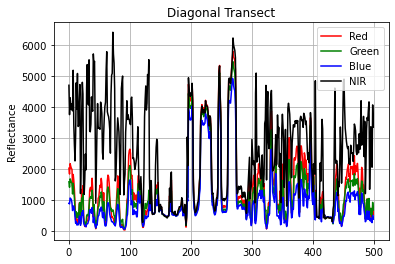

```python
plt.figure()
plt.title('Diagonal Transect')
plt.ylabel('Reflectance')
plt.plot(Red,color='red',label='Red')
plt.plot(Green,color='green',label='Green')
plt.plot(Blue,color='blue',label='Blue')
plt.plot(NIR,color='black',label='NIR')
plt.grid()
plt.legend(loc='upper right')
```

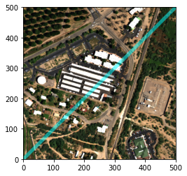

```python
fig, ax = plt.subplots()

x=np.array(0)
for i in range(500):
    b = i+1
    x=np.append(x,b)
ax.imshow(RGBImage, extent=[0, 500, 0, 500])
ax.plot(x, x, '-', linewidth=5, color='cyan', alpha=0.5)
```

```python
#display a message to know the program ended
print("program ended.")
```

```
program ended.
```

### Exercise 3

```python
# load library modules
import os
import numpy as np
import matplotlib.pyplot as plt

#Notice this is a new library with additonal functionality
import viplab_lib2 as vip
```

```python
# Read MODIS simulated data
MODIS_file="MODIS_NEON_GreenValley.bsq"
MODIS_nrows=17
MODIS_ncols=15
#MODIS bands: BLUE, GREEN, RED, NIR
MODIS_nbands=4
# read all 4 bands from simulated MODIS
DataMODIS=vip.BSQ_band_read(MODIS_file,-4,MODIS_nrows,MODIS_ncols)
```

```python
# Read Landsat simulated data
LANDSAT_file="LANDSAT_NEON_GreenValley.bsq"
LANDSAT_nrows=128
LANDSAT_ncols=153
#LANDSAT bands: BLUE, GREEN, RED, NIR, SWIR1, SWIR2
LANDSAT_nbands=6
DataLANDSAT=vip.BSQ_band_read(LANDSAT_file,-6,LANDSAT_nrows,LANDSAT_ncols)
```

```python
# Read NEON Hyperspectral data
NEON_file="NEON_GreenValley2.bsq"
NEON_nrows=656
NEON_ncols=3100
NEON_nbands=100 # We are only reading a subset of the hyperspectral bands

DataNEON=vip.BSQ_band_read(NEON_file,-100,NEON_nrows,NEON_ncols)
```

# Let us learn how to set/use multiple plots/figures on a single Canvas

- More info in this link https://python-course.eu/numerical-programming/creating-subplots-in-matplotlib.php

```python
# bandRED=48
# bandGREEN=34
# bandBLUE=17
# bandNIR=97
```

```python
# Create the RGB images
NEON_RGBImage=vip.Image_getRGB(DataNEON[:,:,48],DataNEON[:,:,34],DataNEON[:,:,17],8000)
MODIS_RGBImage=vip.Image_getRGB(DataMODIS[:,:,2],DataMODIS[:,:,1],DataMODIS[:,:,0],8000)
LandSat_RGBImage=vip.Image_getRGB(DataLANDSAT[:,:,2],DataLANDSAT[:,:,1],DataLANDSAT[:,:,0],8000)
```

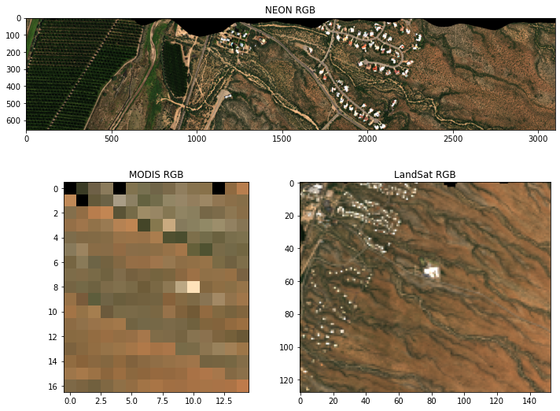

```python
# Here is one way. There are many different ways
# Define a plot canvas . in this case a 2 by 2 matrix/table. Meaning two Rows and two columns of plots
import matplotlib.gridspec as gridspec

plt.figure(figsize=(10, 8))
G = gridspec.GridSpec(2, 2)

# Top row plot/image
axes_1 = plt.subplot(G[0, :])
axes_1.set_title('NEON RGB')
axes_1.imshow(NEON_RGBImage)

# Bottom left plot
axes_1 = plt.subplot(G[1, 0])
axes_1.set_title('MODIS RGB')
axes_1.imshow(MODIS_RGBImage)

# Bottom rigth plot
axes_1 = plt.subplot(G[1, 1])
axes_1.set_title('LandSat RGB')
axes_1.imshow(LandSat_RGBImage)

plt.tight_layout()
plt.show()
```

```python
# Now extract data from all sensors and plot the data

# Get MODIS Reflectance values from each band
PixelMODIS=DataMODIS[1,4,:]
# Set MODIS wavelenght (midpoint band)
# You should know by now that these are the MODIS bands
WaveMODIS=[469,555,645,858]
```

```python
# Get LANDSAT Reflectance values
PixelLANDSAT=DataLANDSAT[12,38,:]
# Set LANDSAR wavelength
WaveLANDSAT=[480,560,655,865,1610,2200]
```

```python
# Do the same for NEON
PixelNEON=DataNEON[328,1950,:]
# Read the wavelength values from the textfile
file = open('NEON_wavelength_values2.txt', 'r')
Xvalues= file.readlines()
nvalues=len(Xvalues)

#convert text to number (float)
for i in range(0,nvalues):
  Xvalues[i]=float(Xvalues[i])

# close text file
file.close
```

```
<function TextIOWrapper.close()>
```

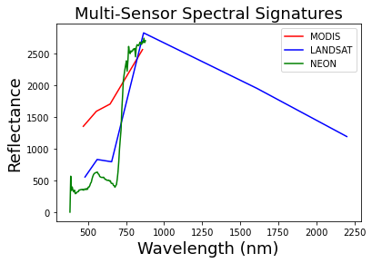

```python
#Now plot all signatures
plt.figure()
plt.title('Multi-Sensor Spectral Signatures', fontsize = 18)
plt.xlabel('Wavelength (nm)', fontsize = 18)
plt.ylabel('Reflectance', fontsize = 18)
plt.plot(WaveMODIS,PixelMODIS, color="red", label="MODIS")
plt.plot(WaveLANDSAT,PixelLANDSAT,color="blue", label="LANDSAT")
plt.plot(Xvalues,PixelNEON,color="green",label="NEON")
plt.legend(loc='upper right')
```

# Homework: To do

- Extract additional example spectras from the different sensors
- Following EX-2 extract Row/Column/Transect from the different sensors and compare them.
- Why the differences?  
  *Because the resolutions are so wildly different for these satellites, their relative reflectance and spectral sensors are going to vary greatly. DT*

```python
# Now extract data from all sensors and plot the data

# Get MODIS Reflectance values from each band
PixelMODIS=DataMODIS[0,4,:]
# Set MODIS wavelenght (midpoint band)
# You should know by now that these are the MODIS bands
WaveMODIS=[469,555,645,858]
```

```python
# Get LANDSAT Reflectance values
PixelLANDSAT=DataLANDSAT[5,95,:]
# Set LANDSAR wavelength
WaveLANDSAT=[480,560,655,865,1610,2200]
```

```python
# Do the same for NEON
PixelNEON=DataNEON[100,1000,:]
# Read the wavelength values from the textfile
file = open('NEON_wavelength_values2.txt', 'r')
Xvalues= file.readlines()
nvalues=len(Xvalues)

#convert text to number (float)
for i in range(0,nvalues):
  Xvalues[i]=float(Xvalues[i])

# close text file
file.close
```

```
<function TextIOWrapper.close()>
```

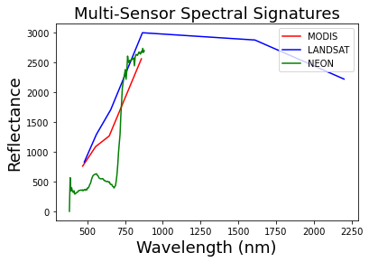

```python
#Now plot all signatures
plt.figure()
plt.title('Multi-Sensor Spectral Signatures', fontsize = 18)
plt.xlabel('Wavelength (nm)', fontsize = 18)
plt.ylabel('Reflectance', fontsize = 18)
plt.plot(WaveMODIS,PixelMODIS, color="red", label="MODIS")
plt.plot(WaveLANDSAT,PixelLANDSAT,color="blue", label="LANDSAT")
plt.plot(Xvalues,PixelNEON,color="green",label="NEON")
plt.legend(loc='upper right')
```

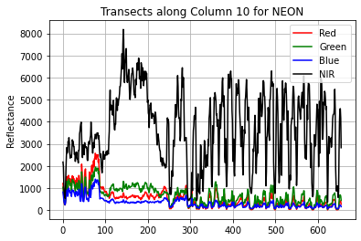

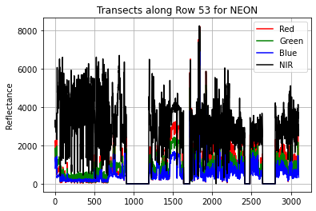

[figure not shown]

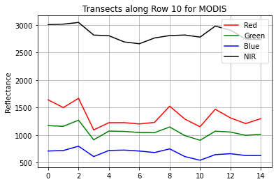

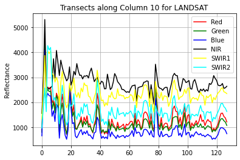

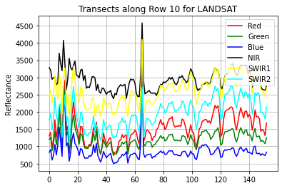

```python
bandRED=48
bandGREEN=34
bandBLUE=17
bandNIR=97
bandSWIR1 = 4
bandSWIR2 = 5

row = 53
c = 10
DataCube = DataNEON

Row_Red=DataCube[:,c,bandRED]
Row_Green=DataCube[:,c,bandGREEN]
Row_Blue=DataCube[:,c,bandBLUE]
Row_NIR=DataCube[:,c,bandNIR]
plt.figure()
plt.title('Transects along Column ' + str(c) + ' for NEON')
plt.ylabel('Reflectance')
plt.plot(Row_Red,color='red',label='Red')
plt.plot(Row_Green,color='green',label='Green')
plt.plot(Row_Blue,color='blue',label='Blue')
plt.plot(Row_NIR,color='black',label='NIR')
plt.grid()
plt.legend(loc='upper right')

Row_Red=DataCube[row,:,bandRED]
Row_Green=DataCube[row,:,bandGREEN]
Row_Blue=DataCube[row,:,bandBLUE]
Row_NIR=DataCube[row,:,bandNIR]
plt.figure()
plt.title('Transects along Row ' + str(row) + ' for NEON')
plt.ylabel('Reflectance')
plt.plot(Row_Red,color='red',label='Red')
plt.plot(Row_Green,color='green',label='Green')
plt.plot(Row_Blue,color='blue',label='Blue')
plt.plot(Row_NIR,color='black',label='NIR')
plt.grid()
plt.legend(loc='upper right')

#MODIS bands: BLUE, GREEN, RED, NIR
row = 10
c = 10
DataCube = DataMODIS

Row_Red=DataCube[:,c,2]
Row_Green=DataCube[:,c,1]
Row_Blue=DataCube[:,c,0]
Row_NIR=DataCube[:,c,3]
# Row_SWIR1=DataCube[:,c,4]
# Row_SWIR2=DataCube[:,c,5]
plt.figure()
plt.title('Transects along Column ' + str(c) + ' for LANDSAT')
plt.ylabel('Reflectance')
plt.plot(Row_Red,color='red',label='Red')
plt.plot(Row_Green,color='green',label='Green')
plt.plot(Row_Blue,color='blue',label='Blue')
plt.plot(Row_NIR,color='black',label='NIR')
# plt.plot(Row_SWIR1,color='yellow',label='SWIR1')
# plt.plot(Row_SWIR2,color='cyan',label='SWIR2')
plt.grid()
plt.legend(loc='upper right')

Row_Red=DataCube[row,:,2]
Row_Green=DataCube[row,:,1]
Row_Blue=DataCube[row,:,0]
Row_NIR=DataCube[row,:,3]
plt.figure()
plt.title('Transects along Row ' + str(row) + ' for MODIS')
plt.ylabel('Reflectance')
plt.plot(Row_Red,color='red',label='Red')
plt.plot(Row_Green,color='green',label='Green')
plt.plot(Row_Blue,color='blue',label='Blue')
plt.plot(Row_NIR,color='black',label='NIR')
plt.grid()
plt.legend(loc='upper right')

#LANDSAT bands: BLUE, GREEN, RED, NIR, SWIR1, SWIR2
row = 10
c = 10
DataCube = DataLANDSAT

Row_Red=DataCube[:,c,2]
Row_Green=DataCube[:,c,1]
Row_Blue=DataCube[:,c,0]
Row_NIR=DataCube[:,c,3]
Row_SWIR1=DataCube[:,c,4]
Row_SWIR2=DataCube[:,c,5]
plt.figure()
plt.title('Transects along Column ' + str(c) + ' for LANDSAT')
plt.ylabel('Reflectance')
plt.plot(Row_Red,color='red',label='Red')
plt.plot(Row_Green,color='green',label='Green')
plt.plot(Row_Blue,color='blue',label='Blue')
plt.plot(Row_NIR,color='black',label='NIR')
plt.plot(Row_SWIR1,color='yellow',label='SWIR1')
plt.plot(Row_SWIR2,color='cyan',label='SWIR2')
plt.grid()
plt.legend(loc='upper right')

Row_Red=DataCube[row,:,2]
Row_Green=DataCube[row,:,1]
Row_Blue=DataCube[row,:,0]
Row_NIR=DataCube[row,:,3]
Row_SWIR1=DataCube[row,:,4]
Row_SWIR2=DataCube[row,:,5]
plt.figure()
plt.title('Transects along Row ' + str(row) + ' for LANDSAT')
plt.ylabel('Reflectance')
plt.plot(Row_Red,color='red',label='Red')
plt.plot(Row_Green,color='green',label='Green')
plt.plot(Row_Blue,color='blue',label='Blue')
plt.plot(Row_NIR,color='black',label='NIR')
plt.plot(Row_SWIR1,color='yellow',label='SWIR1')
plt.plot(Row_SWIR2,color='cyan',label='SWIR2')
plt.grid()
plt.legend(loc='upper right')
```

```python
#display a message to know the program ended
print("program ended.")
```

```
program ended.
```